# Book-DFT-Quantum Espresso

## Introduction

The original dft-book was written for VASP by John Kitchin (https://github.com/jkitchin/dft-book). In this book, we are rewriting some of that book for use with Quantum Espresso, ASE and xespresso module (https://github.com/superstar54/xespresso).

## Atomic Simulation Environment

The Atomic Simulation Environment (ASE) is a set of tools and Python modules for setting up, manipulating, running, visualizing and analyzing atomistic simulations. For the introduction of ASE , please visit https://wiki.fysik.dtu.dk/ase/index.html

## Molecules

### Energy and forces

Here is an example of getting the energy and forces from a CO molecule.

```python
from ase import Atoms, Atom
from ase.io import write
from ase.visualize import view
co = Atoms([Atom('C', [0., 0., 0.]),
               Atom('O', [1.2, 0., 0.])],
              cell=(10, 10, 10))
view(co, viewer = 'x3d')
```

```python
from xespresso import Espresso
pseudopotentials = {'O': 'O.pbe-n-rrkjus_psl.1.0.0.UPF',
                    'C': 'C.pbe-n-rrkjus_psl.1.0.0.UPF'}
queue = {'ntasks': 4, 'account': None, 'partition': 'debug', 'time': '00:10:00'}
calc = Espresso(label = 'molecule/co-energy-force/co-energy-force',
                pseudopotentials = pseudopotentials,
                ecutwfc = 30,
                tprnfor = True,
                kpts = (1, 1, 1),
                queue = queue,
               )
co.calc = calc
co.get_potential_energy()
calc.read_results()
print('Energy = {0:1.3f} eV'.format(calc.results['energy']))
print('Forces: \n', calc.results['forces'])
```

```
Energy = -606.967 eV
Forces:
 [[ 4.13462056  0.          0.        ]
 [-4.13462056  0.          0.        ]]
```

### Convergence with unit cell size

```
4 -607.818
5 -607.093
6 -606.720
8 -606.961
10 -606.967
```

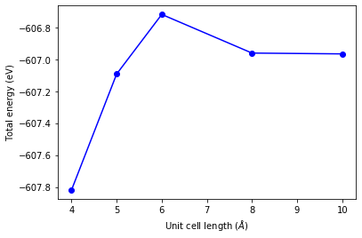

```python
import matplotlib.pyplot as plt
L = [4, 5, 6, 8, 10]
energies = []
for a in L:
    atoms = co.copy()
    atoms.set_cell([a, a, a], scale_atoms=False)
    calc = Espresso(label = 'molecule/co-cell-{0}/co-cell-{0}'.format(a),
                    pseudopotentials = pseudopotentials,
                    ecutwfc = 30,
                    kpts = (1, 1, 1),
                    queue = queue)
    atoms.calc = calc
    e = atoms.get_potential_energy()
    print('{0} {1:3.3f}'.format(a, e))
    energies.append(e)

plt.plot(L, energies, 'bo-')
plt.xlabel('Unit cell length ($\AA$)')
plt.ylabel('Total energy (eV)')
plt.savefig('images/co-cell-energy.png')
```

For small box sizes, the CO molecule is more stable (energy is more negative), because there are attractive interactions between the CO molecules.

### Convergence of ECUTWFC

The total energy and forces also depend on the computational parameters, notably ecutwfc.

```
5 -494.172
10 -540.971
15 -559.170
20 -582.412
25 -601.056
30 -606.967
35 -608.217
40 -608.473
```

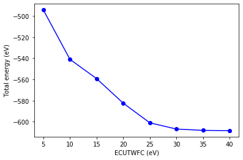

```python
ecutwfcs = [5, 10, 15, 20, 25, 30, 35, 40]
energies = []
for ecutwfc in ecutwfcs:
    calc = Espresso(label = 'molecule/co-ecutwfc-{0}/co-ecutwfc-{0}'.format(ecutwfc),
                    pseudopotentials = pseudopotentials,
                    ecutwfc = ecutwfc,
                    kpts = (1, 1, 1),
                    queue = queue)
    atoms = co.copy()
    atoms.calc = calc
    e = atoms.get_potential_energy()
    print('{0} {1:3.3f}'.format(ecutwfc, e))
    energies.append(e)

plt.plot(ecutwfcs, energies, 'bo-')
plt.xlabel('ECUTWFC (eV)')
plt.ylabel('Total energy (eV)')
plt.savefig('images/co-ecutwfc-energy.png')
```

### Density of states (DOS)

The density of states (DOS) gives you the number of electronic states (i.e., the orbitals) that have a particular energy. For insulator, the number of electronic states (bands) to be calculated is the number of valence bands (nbnd). For CO, nbnd = (4+6)/2 = 5. More bands can be setted, if we want to see the dos above the fermi energy.

```
Energy  = -606.966562188874 eV
molecule/co-dos/nscf/co-dos.save
------------------------------

 nscf calculation in molecule/co-dos/nscf ......
running dos
sbatch .job_file
```

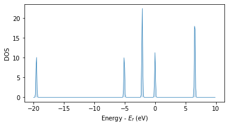

```python
from xespresso.dos import DOS
import matplotlib.pyplot as plt

pseudopotentials = {'O': 'O.pbe-n-rrkjus_psl.1.0.0.UPF',
                    'C': 'C.pbe-n-rrkjus_psl.1.0.0.UPF'}
calc = Espresso(label = 'molecule/co-dos/co-dos',
                pseudopotentials = pseudopotentials,
                ecutwfc = 30,
                nbnd = 7,
                kpts = (1, 1, 1),
                queue = queue)
co.calc = calc
e = co.get_potential_energy()
print('Energy  = {0} eV'.format(e))
calc.read_results()
fermi = calc.get_fermi_level()
calc.nscf(queue = queue, type = 'dos', kpts = (1, 1, 1))
calc.nscf_calculate()
calc.post(queue = queue, package = 'dos', Emin = fermi - 20, Emax = fermi + 10, DeltaE = 0.1)
dos = DOS(calc)
dos.read_dos()
dos.plot_dos(Emin = -20, Emax = 10)
plt.xlabel('Energy - $E_f$ (eV)')
plt.ylabel('DOS')
plt.savefig('images/co-dos.png')
```

### Atom-projected density of states (PDOS)

```
running projwfc
sbatch .job_file
```

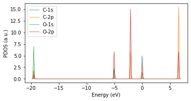

```python
calc.post(queue = queue, package = 'projwfc', Emin = fermi - 20, Emax = fermi + 10, DeltaE = 0.1)
dos.read_pdos()
dos.plot_pdos(Emin = -20, Emax = 10, legend = True)
plt.savefig('images/co-pdos.png')
```

### Geometry optimization

```
1.05 -606.210
1.1 -606.837
1.15 -607.052
1.2 -606.967
1.25 -606.667
```

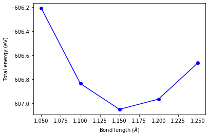

```python
bond_lengths = [1.05, 1.1, 1.15, 1.2, 1.25]
energies = []
for x in bond_lengths:
    calc = Espresso(label = 'molecule/co-bond-{0}/co-bond-{0}'.format(x),
                    pseudopotentials = pseudopotentials,
                    ecutwfc = 30,
                    kpts = (1, 1, 1),
                    queue = queue)
    atoms = co.copy()
    atoms[1].x = x
    atoms.calc = calc
    e = atoms.get_potential_energy()
    print('{0} {1:3.3f}'.format(x, e))
    energies.append(e)

plt.plot(bond_lengths, energies, 'bo-')
plt.xlabel(r'Bond length ($\AA$)')
plt.ylabel('Total energy (eV)')
plt.savefig('images/co-bondlengths.png')
```

## Bulk systems

### Structure

```python
from ase.build import bulk
ag = bulk('Ag', cubic = True)
view(ag*[3, 3, 3], viewer = 'x3d')
```

### Energy and forces

```python
from xespresso import Espresso

pseudopotentials = {'Ag': 'Ag.pbe-n-rrkjus_psl.1.0.0.UPF'}
calc = Espresso(label = 'bulk/ag-energy-force/ag-energy-force',
                pseudopotentials = pseudopotentials,
                ecutwfc = 30,
                smearing = 'gaussian',
                degauss = 0.01,
                tprnfor = True,
                kpts = (12, 12, 12),
                queue = queue)
ag.calc = calc
# ag.get_potential_energy()
calc.read_results()
e = calc.results['energy']/4
forces = calc.results['forces']
print('Energy = {0:1.3f} eV'.format(e))
print('Forces: \n', forces)
```

```
Energy = -1145.201 eV
Forces:
 [[0. 0. 0.]
 [0. 0. 0.]
 [0. 0. 0.]
 [0. 0. 0.]]
```

### k-point convergence

```
4 -1145.083
6 -1145.155
8 -1145.177
10 -1145.193
12 -1145.201
14 -1145.203
```

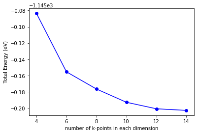

```python
kpts = [4, 6, 8, 10, 12, 14]
energies = []
for kpt in kpts:
    atoms = ag.copy()
    calc = Espresso(label = 'bulk/ag-kpts-{0}/ag-kpts-{0}'.format(kpt),
                    pseudopotentials = pseudopotentials,
                    ecutwfc = 30,
                    smearing = 'gaussian',
                    degauss = 0.01,
                    kpts = (kpt, kpt, kpt),
                    queue = queue)
    atoms.calc = calc
#     atoms.get_potential_energy()
    atoms.calc.read_results()
    e = atoms.calc.results['energy']/4
    print('{0} {1:3.3f}'.format(kpt, e))
    energies.append(e)

plt.plot(kpts, energies, 'bo-')
plt.xlabel('Number of k-points in each dimension')
plt.ylabel('Total Energy (eV)')
plt.savefig('images/Ag-kpt-convergence.png')
```

### Density of states (DOS)

```
total valence: 44.0, nbnd: 22
bulk/ag-dos/nscf/ag-dos.save
------------------------------

 nscf calculation in bulk/ag-dos/nscf ......
running dos
sbatch .job_file
```

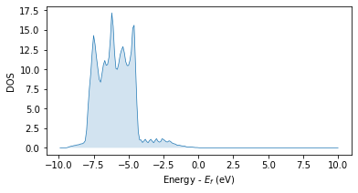

```python
from xespresso import Espresso
from xespresso.dos import DOS
from xespresso.tools import get_nbnd
import matplotlib.pyplot as plt

queue = {'ntasks': 4, 'account': None, 'partition': 'debug', 'time': '00:10:00'}
pseudopotentials = {'Ag': 'Ag.pbe-n-rrkjus_psl.1.0.0.UPF'}
nbnd = int(get_nbnd(ag, pseudopotentials)*1.2)
calc = Espresso(label = 'bulk/ag-dos/ag-dos',
                pseudopotentials = pseudopotentials,
                ecutwfc = 30,
                smearing = 'gaussian',
                degauss = 0.01,
                tprnfor = True,
#                 nbnd = nbnd,
                kpts = (12, 12, 12),
                queue = queue)
ag.calc = calc
ag.get_potential_energy()
calc.read_results()
fermi = calc.get_fermi_level()
calc.nscf(queue = queue, type = 'dos', kpts = (20, 20, 20))
calc.nscf_calculate()
calc.post(queue = queue, package = 'dos', Emin = fermi - 20, Emax = fermi + 10, DeltaE = 0.1)
dos = DOS(calc)
dos.read_dos()
dos.plot_dos(Emin = -10, Emax = 10)
plt.xlabel('Energy - $E_f$ (eV)')
plt.ylabel('DOS')
plt.savefig('images/ag-dos.png')
```

### Atom-projected density of states (PDOS)

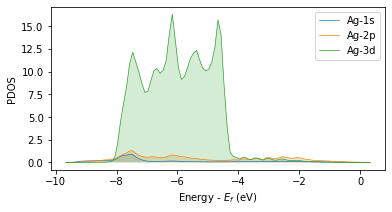

```python
calc.post(queue = queue, package = 'projwfc', Emin = fermi - 20, Emax = fermi + 10, DeltaE = 0.1)
dos = DOS(calc)
dos.read_pdos()
dos.plot_pdos(Emin = -10, Emax = 3, legend = True)
plt.xlabel('Energy - $E_f$ (eV)')
plt.ylabel('PDOS')
plt.savefig('images/ag-pdos.png')
```

### Band structures

```python
from ase.build import bulk
from ase.visualize import view
si = bulk('Si')
view(si*[2, 2, 2], viewer = 'x3d')
```

[output not shown]

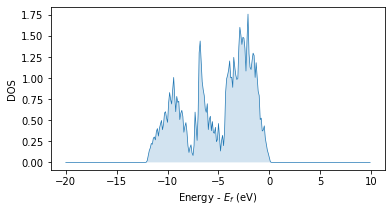

```python
from xespresso import Espresso
from xespresso.dos import DOS
from xespresso.tools import get_nbnd
import matplotlib.pyplot as plt

queue = {'ntasks': 4, 'account': None, 'partition': 'debug', 'time': '00:10:00'}
pseudopotentials = {'Si': 'Si.pbe-n-rrkjus_psl.1.0.0.UPF'}
calc = Espresso(label = 'bulk/si-band/si-band',
                pseudopotentials = pseudopotentials,
                ecutwfc = 30,
                smearing = 'gaussian',
                degauss = 0.01,
                tprnfor = True,
#                 nbnd = nbnd,
                kpts = (8, 8, 8),
                queue = queue,
               )
si.calc = calc
# si.get_potential_energy()
calc.read_results()
fermi = calc.get_fermi_level()
calc.nscf(queue = queue, kpts = (16, 16, 16))
# calc.nscf_calculate()
# calc.post(queue = queue, package = 'dos', Emin = fermi - 20, Emax = fermi + 10, DeltaE = 0.1)
dos = DOS(calc)
dos.read_dos()
dos.plot_dos(Emin = -20, Emax = 10)
plt.xlabel('Energy - $E_f$ (eV)')
plt.ylabel('DOS')
plt.savefig('images/si-dos.png')
```

```
bulk/si-band
```

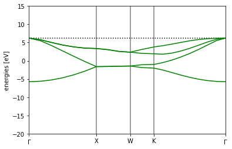

```python
calc = si.calc
print(calc.scf_directory)
kpts={'path': 'GXWKG', 'npoints': 20}
calc.nscf(queue = queue, calculation = 'bands', kpts = kpts)
# calc.nscf_calculate()
calc.read_results()
bs = calc.band_structure()
bs._reference = fermi
ax = bs.plot(emin = -20, emax=15)
plt.savefig('images/si-band.png')
```

## Advanced electronic structure methods

### Spin and DFT + U

```python
from ase.build import bulk
from ase.visualize import view
from xespresso import Espresso

fe = bulk('Fe', cubic = True)
# set new species for afm state
fe.arrays['species'] = fe.get_chemical_symbols()
fe.arrays['species'][1] = 'Fe1'
input_ntyp = {
'starting_magnetization': {'Fe': 1.0, 'Fe1': -1.0, },
'Hubbard_U': {'Fe': 4.3, 'Fe1': 4.3},
}
input_data = {
'ecutwfc': 40.0,
'occupations': 'smearing',
'smearing': 'gaussian',
'degauss': 0.03,
'nspin': 2,
'input_ntyp': input_ntyp,
}
pseudopotentials = {
'Fe': 'Fe.pbe-spn-rrkjus_psl.1.0.0.UPF',
'Fe1': 'Fe.pbe-spn-rrkjus_psl.1.0.0.UPF',
}
queue = {'ntasks': 4, 'account': None, 'partition': 'debug', 'time': '00:10:00'}
calc = Espresso(pseudopotentials = pseudopotentials,
                label  = 'bulk/fe-afm/fe-afm',
                input_data = input_data,
                kpts=(6, 6, 6),
                queue = queue,
               )
fe.calc = calc
e = fe.get_potential_energy()
calc.read_results()
e = calc.results['energy']
print('Energy  {0:1.3f}'.format(e))
```

```
Energy  -6737.243
```

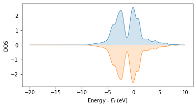

```python
from xespresso.dos import DOS
import matplotlib.pyplot as plt

calc = fe.calc
calc.read_results()
fermi = calc.get_fermi_level()
calc.nscf(queue = queue, kpts = (10, 10, 10))
calc.nscf_calculate()
calc.post(queue = queue, package = 'dos', Emin = fermi - 20, Emax = fermi + 10, DeltaE = 0.1)
dos = DOS(calc)
dos.read_dos()
dos.plot_dos(Emin = -20, Emax = 10)
plt.xlabel('Energy - $E_f$ (eV)')
plt.ylabel('DOS')
plt.savefig('images/fe-afm-dos.png')
```

## Surface

```python
from ase.build import fcc111
from ase.io import write
from ase.visualize import view

pt = fcc111('Pt', size=(1, 1, 3), vacuum=10.0)
from ase.constraints import FixAtoms
constraint = FixAtoms(mask=[atom.tag >= 2 for atom in pt])
pt.set_constraint(constraint)
view(pt*[6, 6, 1], viewer = 'x3d')
```

```python
from xespresso import Espresso
from xespresso.dos import DOS
import matplotlib.pyplot as plt

queue = {'ntasks': 4, 'account': None, 'partition': 'debug', 'time': '00:10:00'}
pseudopotentials = {'Pt': 'Pt.pbe-n-rrkjus_psl.1.0.0.UPF'}
calc = Espresso(label = 'surface/pt/pt',
                pseudopotentials = pseudopotentials,
                ecutwfc = 30,
                smearing = 'gaussian',
                degauss = 0.05,
                mixing_beta = 0.2,
                kpts = (10, 10, 1),
                queue = queue,
               )
pt.calc = calc
pt.get_potential_energy()
calc.read_results()
e = calc.results['energy']
print('Energy  {0:1.3f}'.format(e))
```

```
Energy  -2665.384
```

### Slab with a dipole correction

```python
from xespresso import Espresso
from xespresso.dos import DOS
import matplotlib.pyplot as plt

queue = {'ntasks': 4, 'account': None, 'partition': 'debug', 'time': '00:10:00'}
pseudopotentials = {'Pt': 'Pt.pbe-n-rrkjus_psl.1.0.0.UPF'}
calc = Espresso(label = 'surface/pt-dipole/pt-dipole',
                pseudopotentials = pseudopotentials,
                ecutwfc = 30,
                smearing = 'gaussian',
                degauss = 0.05,
                mixing_beta = 0.2,
                dipfield = True,
                tefield = True,
                edir = 3,      # dipole direction
                emaxpos = 1.0, # dipole position
                kpts = (10, 10, 1),
                queue = queue,
               )
pt.calc = calc
pt.get_potential_energy()
calc.read_results()
e = calc.results['energy']
print('Energy  {0:1.3f}'.format(e))
```

```
Energy  -2665.384
```

### Adsorption

```python
from ase.atoms import Atom
from ase.build import fcc111, add_adsorbate
from ase.io import write
from ase.visualize import view

ads = Atom('O')
pt_o = pt.copy()
add_adsorbate(pt_o, ads, height=1.0, position='fcc')
view(pt_o*[6, 6, 1], viewer = 'x3d')
```

```python
from xespresso import Espresso
from xespresso.dos import DOS
import matplotlib.pyplot as plt

queue = {'ntasks': 10, 'account': None, 'partition': 'debug', 'time': '00:10:00'}
pseudopotentials = {
'Pt': 'Pt.pbe-n-rrkjus_psl.1.0.0.UPF',
'O': 'O.pbe-n-rrkjus_psl.1.0.0.UPF',
}
calc = Espresso(label = 'surface/pt_o/pt_o',
                pseudopotentials = pseudopotentials,
                ecutwfc = 30,
                smearing = 'gaussian',
                degauss = 0.05,
                mixing_beta = 0.2,
                kpts = (10, 10, 1),
                queue = queue,
               )
pt_o.calc = calc
pt_o.get_potential_energy()
calc.read_results()
e = calc.results['energy']
print('Energy  {0:1.3f}'.format(e))
```

```
Energy  -3102.264
```

### with diople correction

```python
from xespresso import Espresso
from xespresso.dos import DOS
import matplotlib.pyplot as plt

queue = {'ntasks': 10, 'account': None, 'partition': 'debug', 'time': '00:10:00'}
pseudopotentials = {
'Pt': 'Pt.pbe-n-rrkjus_psl.1.0.0.UPF',
'O': 'O.pbe-n-rrkjus_psl.1.0.0.UPF',
}
calc = Espresso(label = 'surface/pt-o-dipole/pt-o-dipole',
                pseudopotentials = pseudopotentials,
                ecutwfc = 30,
                smearing = 'gaussian',
                degauss = 0.05,
                mixing_beta = 0.2,
                dipfield = True,
                tefield = True,
                edir = 3,      # dipole direction
                emaxpos = 1.0, # dipole position
                kpts = (10, 10, 1),
                queue = queue,
               )
pt_o.calc = calc
pt_o.get_potential_energy()
calc.read_results()
e = calc.results['energy']
print('Energy  {0:1.3f}'.format(e))
```

```
Energy  -3102.263
```

## Energy Barrier

NEB calculation

#### NH$_3$ inversion

##### initial and final states

```python
from ase.structure import molecule
import numpy as np
from xespresso import Espresso
from ase.constraints import FixAtoms

atoms = molecule('NH3')
atoms.set_cell((10, 10, 10), scale_atoms=False)
constraint = FixAtoms(mask=[atom.symbol == 'N' for atom in atoms])
atoms.set_constraint(constraint)
# move N to origin
atoms.translate(-atoms.positions[0])
initial = atoms.copy()
view(initial, viewer = 'x3d')
```

```python
final = atoms.copy()
final.positions[1:4, :] *= np.array([1, 1, -1])
view(final, viewer = 'x3d')
```

```python
from xespresso import Espresso

jobs = {
'initial': initial,
'final': final,
}
queue = {'ntasks': 10, 'account': None, 'partition': 'debug', 'time': '00:10:00'}
pseudopotentials = {
'N': 'N.pbe-n-rrkjus_psl.1.0.0.UPF',
'H': 'H.pbe-rrkjus_psl.1.0.0.UPF',
}
print('States    Energy (ev)')
for job, atoms in jobs.items():
    calc = Espresso(label = 'molecule/neb/nh3/{0}/{0}'.format(job),
                    pseudopotentials = pseudopotentials,
                    calculation = 'relax',
                    ecutwfc = 30,
                    kpts = (1, 1, 1),
                    queue = queue,
                   )
    atoms.calc = calc
    atoms.get_potential_energy()
    calc.read_results()
    jobs[job] = calc.results['atoms']
    e = calc.results['energy']
    print('{0:10s}  {1:10.3f}'.format(job, e))
```

```
States    Energy (ev)
initial       -326.612
final         -326.612
```

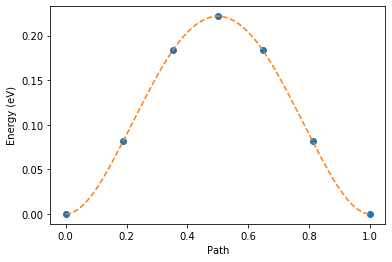

```python
# NEB
from xespresso.neb import NEBEspresso

images = [jobs['initial'], jobs['final']]
path_data = {
'string_method' : 'neb',
'nstep_path': 50,
'opt_scheme': "broyden",
'num_of_images' : 7,
'k_max' : 0.3E0,
'k_min' : 0.2E0,
'CI_scheme' : "auto",
'path_thr': 0.1E0,
}
queue = {'nodes': 2, 'ntasks-per-node': 20, 'account': None, 'partition': 'debug', 'time': '00:10:00'}
calc = NEBEspresso(pseudopotentials = pseudopotentials,
                 label  = 'molecule/neb/nh3/images',
                 package = 'neb',
                 queue = queue,
                 parallel = '-procs 40 -ni 5',
                 images = images,
                 path_data = path_data,
                 ecutwfc = 30,
                 kpts = (1, 1, 1),
                  )
#
calc.calculate()
calc.read_results()
calc.plot()
```

```python
from ase.atoms import Atom
from ase.build import fcc111, add_adsorbate
from ase.io import write
from ase.visualize import view

al = fcc111('Al', size=(2, 1, 3), vacuum=6.0)
from ase.constraints import FixAtoms
constraint = FixAtoms(mask=[atom.tag >= 2 for atom in al])
al.set_constraint(constraint)
ads = Atom('O')
al_o = al.copy()
add_adsorbate(al_o, ads, height=1.0, position='fcc')
view(al_o*[3, 6, 1], viewer = 'x3d')
```

```python
# Initial state:
final = al_o.copy()
final[-1].x += final.get_cell()[0, 0] / 2.0
view(final*[3, 6, 1], viewer = 'x3d')
```

```python
from xespresso import Espresso
from xespresso.dos import DOS
import matplotlib.pyplot as plt

queue = {'ntasks': 10, 'account': None, 'partition': 'debug', 'time': '00:10:00'}
pseudopotentials = {
'Al': 'Al.pbe-n-rrkjus_psl.1.0.0.UPF',
'O': 'O.pbe-n-rrkjus_psl.1.0.0.UPF',
}
calc = Espresso(label = 'surface/neb/al-o/initial/initial',
                pseudopotentials = pseudopotentials,
                calculation = 'relax',
                ecutwfc = 30,
                smearing = 'gaussian',
                degauss = 0.05,
                mixing_beta = 0.2,
                kpts = (5, 10, 1),
                queue = queue,
               )
#
initial = al_o.copy()
initial.calc = calc
# initial.get_potential_energy()
calc.read_results()
initial = calc.results['atoms']
e = calc.results['energy']
print('Initial energy  {0:1.3f}'.format(e))
#
# Final state:
final = al_o.copy()
final[-1].x += final.get_cell()[0, 0] / 4.0
view(final, viewer = 'x3d')
calc = Espresso(label = 'surface/neb/al-o/final/final',
                pseudopotentials = pseudopotentials,
                calculation = 'relax',
                ecutwfc = 30,
                smearing = 'gaussian',
                degauss = 0.05,
                mixing_beta = 0.2,
                kpts = (5, 10, 1),
                queue = queue,
               )
final.calc = calc
# final.get_potential_energy()
calc.read_results()
final = calc.results['atoms']
e = calc.results['energy']
print('Final energy  {0:1.3f}'.format(e))
```

```
Initial energy  -851.472
Final energy  -851.142
```

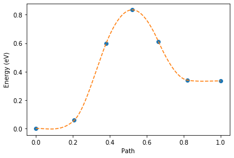

```python
# NEB
from xespresso.neb import NEBEspresso, interploate

images = [initial, final]
# view(interploate(images))
path_data = {
'string_method' : 'neb',
'nstep_path': 50,
'opt_scheme': "broyden",
'num_of_images' : 7,
'k_max' : 0.3E0,
'k_min' : 0.2E0,
'CI_scheme' : "auto",
'path_thr': 0.1E0,
}
queue = {'nodes': 2, 'ntasks-per-node': 20, 'account': None, 'partition': 'debug', 'time': '00:10:00'}
calc = NEBEspresso(pseudopotentials = pseudopotentials,
                 label  = 'surface/neb/al-o/images',
                 package = 'neb',
                 queue = queue,
                 parallel = '-procs 40 -ni 5',
                 images = images,
                 path_data = path_data,
                 ecutwfc = 40,
                 smearing = 'gaussian',
                 degauss = 0.05,
                 mixing_beta = 0.2,
                 kpts = (5, 10, 1),
                  )
#
calc.calculate()
calc.read_results()
calc.plot()
```

### Parallel over kpoint

```
-2461.374 362.400
-2461.374 188.710
-2461.374 172.200
-2461.374 179.040
```

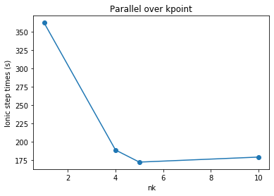

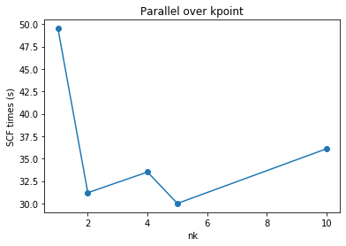

```python
from ase.build import fcc111
from xespresso import Espresso


al111 = fcc111('Al', size = (3, 3, 4), a = 4.0, vacuum = 10.0)
queue = {'nodes': 2, 'ntasks-per-node': 20, 'account': None, 'partition': 'debug', 'time': '00:10:00'}
pseudopotentials = {'Al': 'Al.pbe-n-rrkjus_psl.1.0.0.UPF'}
ts = []
nks = [1, 4, 5, 10]
# nks = [2]
for nk in nks:
    calc = Espresso(label = 'surface/al-nk-{0}/al-nk-{0}'.format(nk),
                pseudopotentials = pseudopotentials,
                ecutwfc = 30,
                smearing = 'gaussian',
                degauss = 0.05,
                mixing_beta = 0.2,
                mixing_model = 'local-TF',
                kpts = (8, 8, 1),
                queue = queue,
                parallel = '-nk {0}'.format(nk),
               )
    al111.calc = calc
#     al111.get_potential_energy()
    calc.read_results()
    e = calc.results['energy']
    t = calc.get_time()
    ts.append(t)
    print('{0:5.3f} {1:5.3f}'.format(e, t))

plt.plot(nks, ts, '-o')
plt.title('Parallel over kpoint')
plt.xlabel('nk')
plt.ylabel('Ionic step times (s)')

plt.figure()
plt.plot([1, 2, 4, 5, 10], [49.5, 31.2, 33.5, 30.0, 36.1], '-o')
plt.title('Parallel over kpoint')
plt.xlabel('nk')
plt.ylabel('SCF times (s)')
```